# BeerSales

Justin Howard, Amber Burnet

June 17, 2019

## Loading the beer data:

```r
file1<- 'C:/Users/howar/Documents/R__working_directory/DDS/msds-6306-doing-data-science/Unit 7/Beers.csv'
Beers<- read.csv(file1)
str(Beers)
```

```
## 'data.frame':    2410 obs. of  7 variables:
##  $ Name      : Factor w/ 2305 levels "#001 Golden Amber Lager",..: 1638 577 1705 1842 1819 268 1160 758 1093 486 ...
##  $ Beer_ID   : int  1436 2265 2264 2263 2262 2261 2260 2259 2258 2131 ...
##  $ ABV       : num  0.05 0.066 0.071 0.09 0.075 0.077 0.045 0.065 0.055 0.086 ...
##  $ IBU       : int  NA NA NA NA NA NA NA NA NA NA ...
##  $ Brewery_id: int  409 178 178 178 178 178 178 178 178 178 ...
##  $ Style     : Factor w/ 100 levels "","Abbey Single Ale",..: 19 18 16 12 16 80 18 22 18 12 ...
##  $ Ounces    : num  12 12 12 12 12 12 12 12 12 12 ...
```

```r
head(Beers)
```

```
##                  Name Beer_ID   ABV IBU Brewery_id
## 1            Pub Beer    1436 0.050  NA        409
## 2         Devil's Cup    2265 0.066  NA        178
## 3 Rise of the Phoenix    2264 0.071  NA        178
## 4            Sinister    2263 0.090  NA        178
## 5       Sex and Candy    2262 0.075  NA        178
## 6        Black Exodus    2261 0.077  NA        178
##                            Style Ounces
## 1            American Pale Lager     12
## 2        American Pale Ale (APA)     12
## 3                   American IPA     12
## 4 American Double / Imperial IPA     12
## 5                   American IPA     12
## 6                  Oatmeal Stout     12
```

## Loading the brewery data:

```r
file2<- 'C:/Users/howar/Documents/R__working_directory/DDS/msds-6306-doing-data-science/Unit 7/Breweries.csv'
Breweries<- read.csv(file2)
str(Breweries)
```

```
## 'data.frame':    558 obs. of  4 variables:
##  $ Brew_ID: int  1 2 3 4 5 6 7 8 9 10 ...
##  $ Name   : Factor w/ 551 levels "10 Barrel Brewing Company",..: 355 12 266 319 201 136 227 477 59 491 ...
##  $ City   : Factor w/ 384 levels "Abingdon","Abita Springs",..: 228 200 122 299 300 62 91 48 152 136 ...
##  $ State  : Factor w/ 51 levels " AK"," AL"," AR",..: 24 18 20 5 5 41 6 23 23 23 ...
```

```r
head(Breweries)
```

```
##   Brew_ID                      Name          City State
## 1       1        NorthGate Brewing    Minneapolis    MN
## 2       2 Against the Grain Brewery    Louisville    KY
## 3       3  Jack's Abby Craft Lagers    Framingham    MA
## 4       4 Mike Hess Brewing Company     San Diego    CA
## 5       5   Fort Point Beer Company San Francisco    CA
## 6       6     COAST Brewing Company    Charleston    SC
```

## Merging the two datasets on “Brewery_id”

```r
names(Breweries)<- c("Brewery_id", "Brewery_Name", "City", "State")
BeerNBrew<- merge(Beers, Breweries, by = "Brewery_id")
head(BeerNBrew)
```

```
##   Brewery_id          Name Beer_ID   ABV IBU
## 1          1  Get Together    2692 0.045  50
## 2          1 Maggie's Leap    2691 0.049  26
## 3          1    Wall's End    2690 0.048  19
## 4          1       Pumpion    2689 0.060  38
## 5          1    Stronghold    2688 0.060  25
## 6          1   Parapet ESB    2687 0.056  47
##                                 Style Ounces       Brewery_Name
## 1                        American IPA     16 NorthGate Brewing
## 2                  Milk / Sweet Stout     16 NorthGate Brewing
## 3                   English Brown Ale     16 NorthGate Brewing
## 4                         Pumpkin Ale     16 NorthGate Brewing
## 5                     American Porter     16 NorthGate Brewing
## 6 Extra Special / Strong Bitter (ESB)     16 NorthGate Brewing
##          City State
## 1 Minneapolis    MN
## 2 Minneapolis    MN
## 3 Minneapolis    MN
## 4 Minneapolis    MN
## 5 Minneapolis    MN
## 6 Minneapolis    MN
```

```r
tail(BeerNBrew)
```

```
##      Brewery_id                      Name Beer_ID   ABV IBU
## 2405        556             Pilsner Ukiah      98 0.055  NA
## 2406        557  Heinnieweisse Weissebier      52 0.049  NA
## 2407        557           Snapperhead IPA      51 0.068  NA
## 2408        557         Moo Thunder Stout      50 0.049  NA
## 2409        557         Porkslap Pale Ale      49 0.043  NA
## 2410        558 Urban Wilderness Pale Ale      30 0.049  NA
##                        Style Ounces                  Brewery_Name
## 2405         German Pilsener     12         Ukiah Brewing Company
## 2406              Hefeweizen     12       Butternuts Beer and Ale
## 2407            American IPA     12       Butternuts Beer and Ale
## 2408      Milk / Sweet Stout     12       Butternuts Beer and Ale
## 2409 American Pale Ale (APA)     12       Butternuts Beer and Ale
## 2410        English Pale Ale     12 Sleeping Lady Brewing Company
##               City State
## 2405         Ukiah    CA
## 2406 Garrattsville    NY
## 2407 Garrattsville    NY
## 2408 Garrattsville    NY
## 2409 Garrattsville    NY
## 2410     Anchorage    AK
```

## Counting the number of NA values per column:

```r
na_count<- sapply(BeerNBrew, function(x) sum(is.na(x)))
na_count<- data.frame(na_count)
na_count
```

```
##              na_count
## Brewery_id          0
## Name                0
## Beer_ID             0
## ABV                62
## IBU              1005
## Style               0
## Ounces              0
## Brewery_Name        0
## City                0
## State               0
```

#### Observations:

2 columns contain large numbers of NA values: ABV - 62 IBU - 1005

## How many breweries are in each state?

```r
library(dplyr)
bystate<- BeerNBrew %>%
  group_by(State) %>%
  distinct(Brewery_id)

head(bystate)
```

```
## # A tibble: 6 x 2
## # Groups:   State [5]
##   Brewery_id State
##        <int> <fct>
## 1          1 " MN"
## 2          2 " KY"
## 3          3 " MA"
## 4          4 " CA"
## 5          5 " CA"
## 6          6 " SC"
```

```r
brewcount<- aggregate(Brewery_id ~ State, BeerNBrew, length)

names(brewcount)<- c("State", "Brewery_Count")
head(brewcount)
```

```
##   State Brewery_Count
## 1    AK            25
## 2    AL            10
## 3    AR             5
## 4    AZ            47
## 5    CA           183
## 6    CO           265
```

## Visualize data with a US map

First, prepare the data for the map by adding in state names.

```r
#trimming out whitespace
brewcount$State<- trimws(brewcount$State, which = "both")
# a csv with state names matched to abbreviations
# file<- download.file('http://www.whypad.com/wp-content/uploads/us_states.zip')
state.abbv<- read.csv('us_states.csv', header = F)
#give the columns names to reference by
names(state.abbv)<- c("State.Caps", "State.Name", "State")
#select only data we need
addin<- state.abbv %>%
  select(State.Name, State)
# make all state names lowercase to match states data
addin$State.Name<- tolower(addin$State.Name)
#merge with brewcount dataframe
brewcount.states<- merge(brewcount, addin, by = "State")

#loading packages
library(ggmap)
```

```r
library(maps)
library(mapdata)

#make dataframe of states and merge with our data
states <- map_data("state")
addbrews<- brewcount.states %>%
  select(Brewery_Count, State.Name)
names(addbrews)<- c("Brewery_Count", "region")
#brewery.map.data<-merge(states, addbrews, by = "region", all.x = T)
#using merge in this case causes rips in the map, instead, use left_join from dplyr
brewery.map.data2<- left_join(states, addbrews)
```

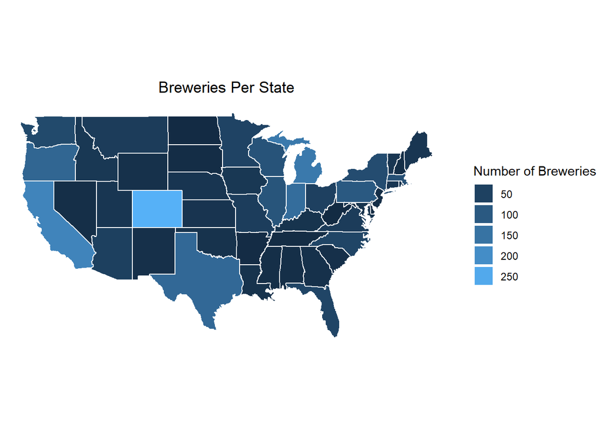

```r
ggplot(data = brewery.map.data2) +
  ggtitle("Breweries Per State") +
  theme(plot.title = element_text(hjust = .5)) +
  geom_polygon(aes(x = long, y = lat, fill = Brewery_Count, group = group), color = "white") +
  coord_fixed(1.3) + theme_nothing(legend = T) + guides(fill=guide_legend(title = "Number of Breweries"))
```

```r
#load data with state populations
pops<- read.csv('C:/Users/howar/Documents/doingdatascience/beersales/statepopulations.csv', head=T)
pops<- pops %>%
  select(NAME, POPESTIMATE2018)
pops$NAME<- tolower(pops$NAME)
names(pops) <- c("State.Name", "PopEst2018")
head(pops)
```

```
##         State.Name PopEst2018
## 1    united states  327167434
## 2 northeast region   56111079
## 3   midwest region   68308744
## 4     south region  124753948
## 5      west region   77993663
## 6          alabama    4887871
```

```r
#merging with state names table
brewcount.states<- left_join(brewcount.states, pops)
```

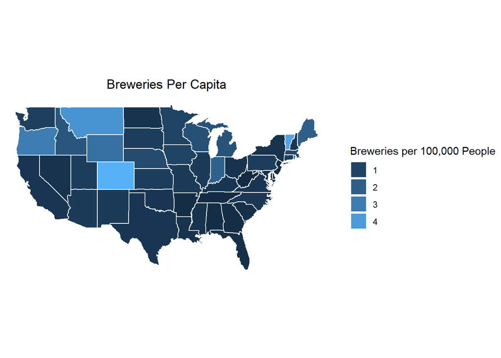

```r
brewcount.states<- brewcount.states %>%
  mutate(Brews.Per.Capita = Brewery_Count / PopEst2018)

# making the new map table
add.per.capita<- brewcount.states %>%
  select(Brews.Per.Capita, State.Name)
names(add.per.capita)<- c("Brews.Per.Capita", "region")

brews.per.capita.map<- left_join(states,add.per.capita)
brews.per.capita.map$Brews.Per.Capita<- round(brews.per.capita.map$Brews.Per.Capita, digits = 6)*100000

ggplot(data = brews.per.capita.map) +
  ggtitle("Breweries Per Capita") +
  theme(plot.title = element_text(hjust = .5)) +
  geom_polygon(aes(x = long, y = lat, fill = Brews.Per.Capita, group = group), color = "white") +
  coord_fixed(1.3) + theme_nothing(legend = T) + guides(fill=guide_legend(title = "Breweries per 100,000 People"))
```

We see that Colorado is still an outlier when we look at the number of breweries per person. Other notable outliers include Vermont, Montana, Oregon and Wyoming.

## Median alcohol content and international bitterness unit for each state.

```r
IBUvals<- BeerNBrew %>%
  group_by(State) %>%
  filter(!is.na(IBU))
head(IBUvals)
```

```
## # A tibble: 6 x 10
## # Groups:   State [1]
##   Brewery_id Name  Beer_ID   ABV   IBU Style Ounces Brewery_Name City
##        <int> <fct>   <int> <dbl> <int> <fct>  <dbl> <fct>        <fct>
## 1          1 Get ~    2692 0.045    50 Amer~     16 "NorthGate ~ Minn~
## 2          1 Magg~    2691 0.049    26 Milk~     16 "NorthGate ~ Minn~
## 3          1 Wall~    2690 0.048    19 Engl~     16 "NorthGate ~ Minn~
## 4          1 Pump~    2689 0.06     38 Pump~     16 "NorthGate ~ Minn~
## 5          1 Stro~    2688 0.06     25 Amer~     16 "NorthGate ~ Minn~
## 6          1 Para~    2687 0.056    47 Extr~     16 "NorthGate ~ Minn~
## # ... with 1 more variable: State <fct>
```

```r
IBUmedians<- aggregate(IBU ~ State, IBUvals, median)
names(IBUmedians)<- c("State", "Median_IBU")
head(IBUmedians)
```

```
##   State Median_IBU
## 1    AK       46.0
## 2    AL       43.0
## 3    AR       39.0
## 4    AZ       20.5
## 5    CA       42.0
## 6    CO       40.0
```

```r
boozecontent<- BeerNBrew %>%
  group_by(State)
boozemedians<- aggregate(ABV ~ State, boozecontent, median)
names(boozemedians)<- c("State", "Median_ABV")
boozemedians<- arrange(boozemedians, boozemedians$Median_ABV)
```

### Bar Charts

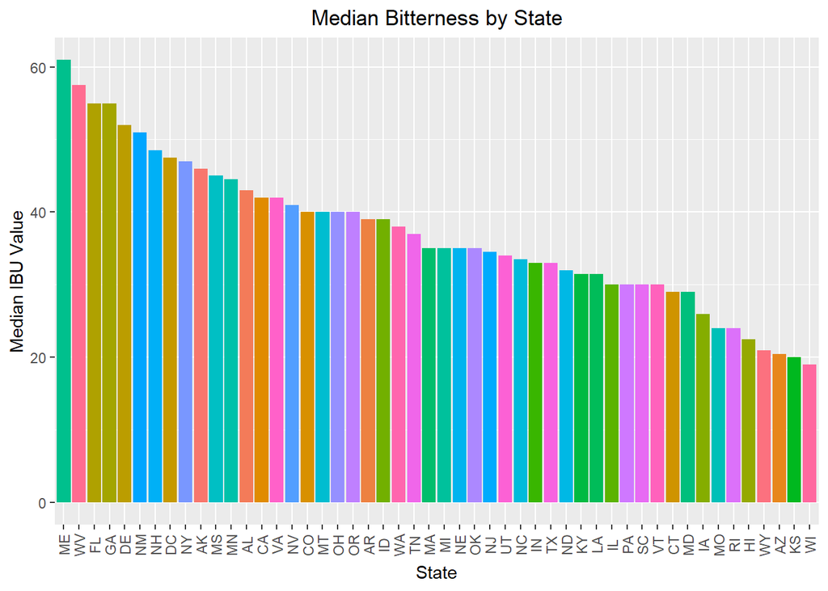

```r
library(ggplot2)
ggplot(IBUmedians, aes(x=reorder(State, -Median_IBU), y=Median_IBU, fill=State)) + geom_bar(stat= 'identity') + guides(fill=F)+ theme(plot.title = element_text(hjust= .5), axis.text.x = element_text(angle=90, vjust = .5)) +
  ggtitle("Median Bitterness by State") + xlab('State') + ylab('Median IBU Value')
```

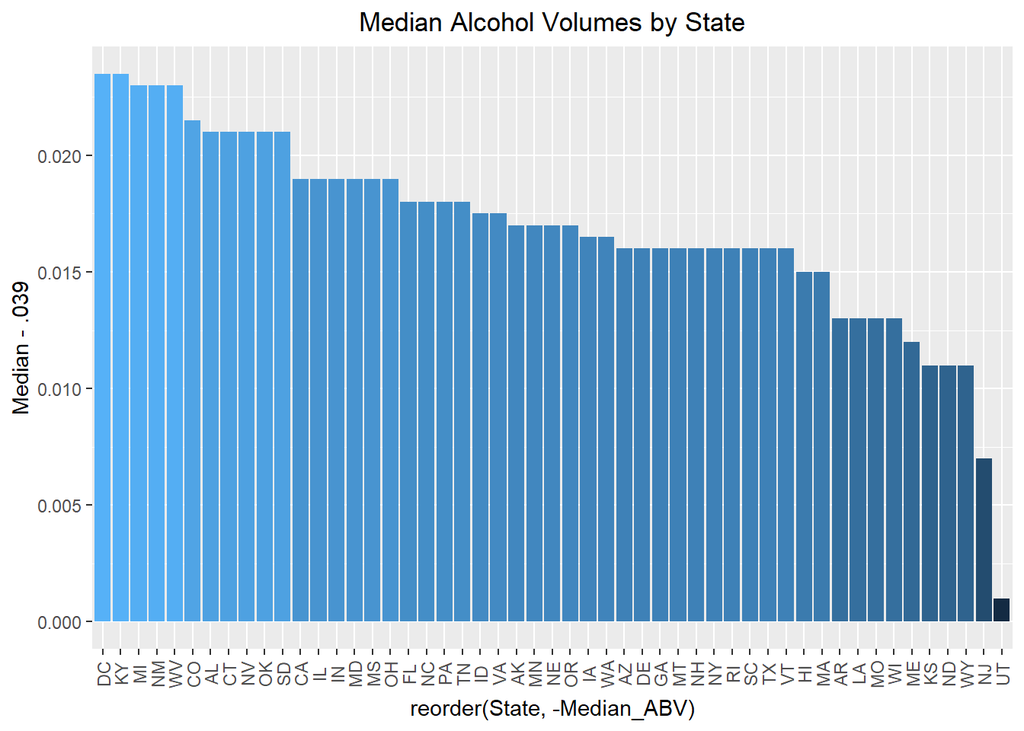

```r
ggplot(boozemedians, aes(x=reorder(State, -Median_ABV), y=(Median_ABV-.039), fill=Median_ABV)) + geom_bar(stat= 'identity') +
  guides(fill=F) + theme(plot.title = element_text(hjust= .5), axis.text.x = element_text(angle=90, vjust = .5)) +
  ggtitle("Median Alcohol Volumes by State") + ylab('Median - .039')
```

Prepping and merging the median IBU the data with the states data.

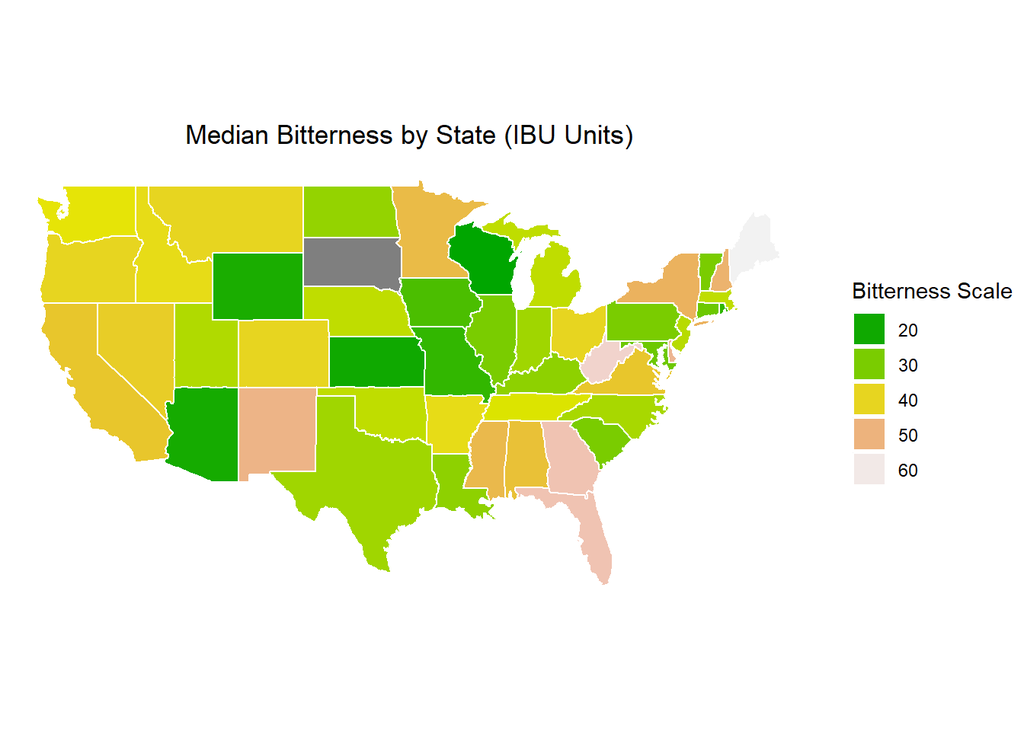

```r
#trimming out whitespace
IBUmedians$State<- trimws(IBUmedians$State, which = "both")

#merge with IBUmedians dataframe
IBUmedians.states<- merge(IBUmedians, addin, by = "State")

addIBU<- IBUmedians.states %>%
  select(Median_IBU, State.Name)
names(addIBU)<- c("Median_IBU", "region")

IBU.map<- left_join(states, addIBU)
ggplot(data = IBU.map) +
  ggtitle("Median Bitterness by State (IBU Units)") +
  theme(plot.title = element_text(hjust = .5)) +
  scale_fill_gradientn(colours=terrain.colors(10)) +
  geom_polygon(aes(x = long, y = lat, fill = Median_IBU, group = group), color = "white") +
  coord_fixed(1.3) + theme_nothing(legend = T) + guides(fill=guide_legend(title = "Bitterness Scale"))
```

The map indicates that Midwestern states tend to contain more breweries with low median reported bitterness than other regions. West Coast states appear to consistently produce beers in the medium bittnerness range, while bitterness varies widely on the East Coast. The East Coast does contain 3 of the states with the highest median bitterness

The wide variance among states indicates that breweries that have reported their bitterness ratings may have a sginficant influence on the available data. Some breweries that specialize in bitter beers make a significant impact on the dataset and could be significantly impacting the ptaste preferences of their entire state.

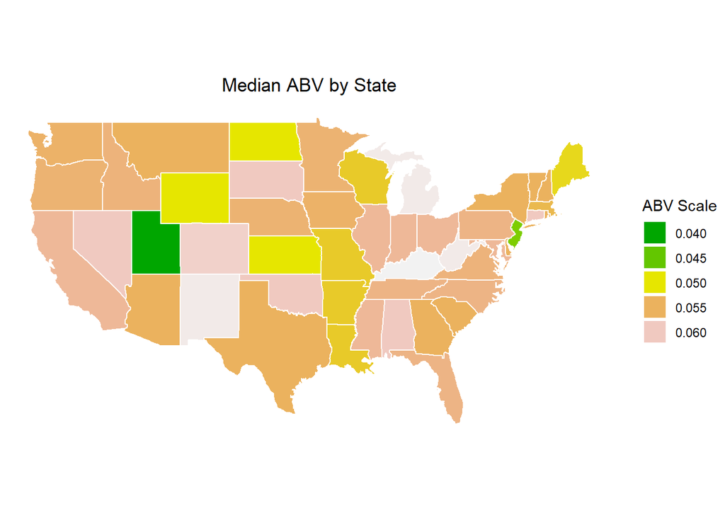

```r
#trimming out whitespace
boozemedians$State<- trimws(boozemedians$State, which = "both")

#merge with IBUmedians dataframe
boozemedians.states<- merge(boozemedians, addin, by = "State")

addABV<- boozemedians.states %>%
  select(Median_ABV, State.Name)
names(addABV)<- c("Median_ABV", "region")

ABV.map<- left_join(states, addABV)
ggplot(data = ABV.map) +
  ggtitle("Median ABV by State") +
  scale_fill_gradientn(colours=terrain.colors(10))+
  theme(plot.title = element_text(hjust = .5)) +
  geom_polygon(aes(x = long, y = lat, fill = Median_ABV, group = group), color = "white") +
  coord_fixed(1.3) + theme_nothing(legend = T) + guides(fill=guide_legend(title = "ABV Scale"))
```

## Maximum Alcoholic(ABV) Beer by State

```r
 maxABV<-max(BeerNBrew$ABV,na.rm=TRUE)
statemaxABV<-filter(BeerNBrew, ABV==maxABV)
statemaxABV %>% select(State,ABV)
```

```
##   State   ABV
## 1    CO 0.128
```

```r
statemaxABV
```

```
##   Brewery_id                                                 Name Beer_ID
## 1         52 Lee Hill Series Vol. 5 - Belgian Style Quadrupel Ale    2565
##     ABV IBU            Style Ounces            Brewery_Name    City State
## 1 0.128  NA Quadrupel (Quad)   19.2 Upslope Brewing Company Boulder    CO
```

## Top 3 States with Highest ABV

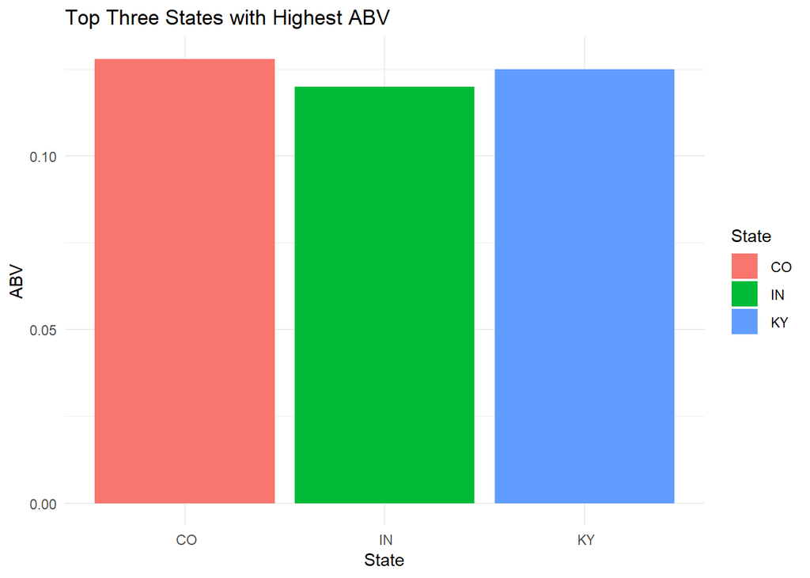

```r
newdata <- BeerNBrew[order(-BeerNBrew$ABV, na.last=TRUE),]
l<-head(newdata,3)
mm<-ggplot(l, aes(x=State,y=ABV,fill=State))+geom_bar(stat="identity")+xlab("State")+ylab("ABV")+ggtitle("Top Three States with Highest ABV")+theme_minimal()
mm
```

## Questin 5 Part B: Maximum IBU Bitterness by State

```r
 maxIBU<-max(BeerNBrew$IBU,na.rm=TRUE)
statemaxIBU<-filter(BeerNBrew, IBU==maxIBU)
statemaxIBU %>% select(State,IBU)
```

```
##   State IBU
## 1    OR 138
```

## Top 3 States with Highes IBU

```r
newdata2 <- BeerNBrew[order(-BeerNBrew$IBU, na.last=TRUE),]
head(newdata2,3)
```

```
##      Brewery_id                      Name Beer_ID   ABV IBU
## 1857        375 Bitter Bitch Imperial IPA     980 0.082 138
## 1719        345        Troopers Alley IPA    1676 0.059 135
## 1305        231             Dead-Eye DIPA    2067 0.090 130
##                               Style Ounces               Brewery_Name
## 1857 American Double / Imperial IPA     12    Astoria Brewing Company
## 1719                   American IPA     12 Wolf Hills Brewing Company
## 1305 American Double / Imperial IPA     16   Cape Ann Brewing Company
##            City State
## 1857    Astoria    OR
## 1719   Abingdon    VA
## 1305 Gloucester    MA
```

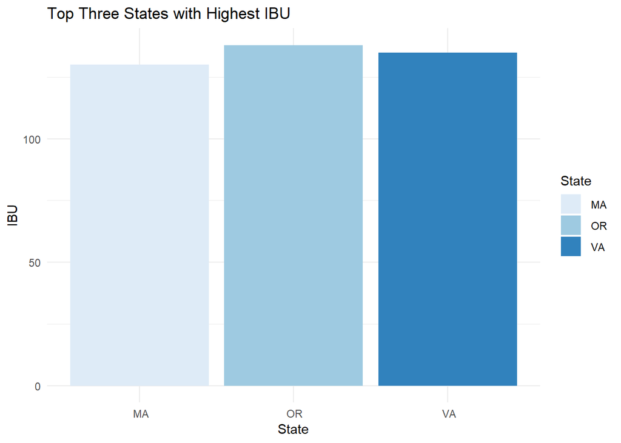

```r
n<-head(newdata2,3)
nn<-ggplot(n, aes(x=State,y=IBU,fill=State))+geom_bar(stat="identity")+xlab("State")+ylab("IBU")+ggtitle("Top Three States with Highest IBU")+theme_minimal()+scale_fill_brewer()
nn
```

## Question 6 Summary Statistics for the ABV Variable by Summary Function

```r
dfa<-(BeerNBrew$ABV)
summary(dfa)
```

```
##    Min. 1st Qu.  Median    Mean 3rd Qu.    Max.    NA's
## 0.00100 0.05000 0.05600 0.05977 0.06700 0.12800      62
```

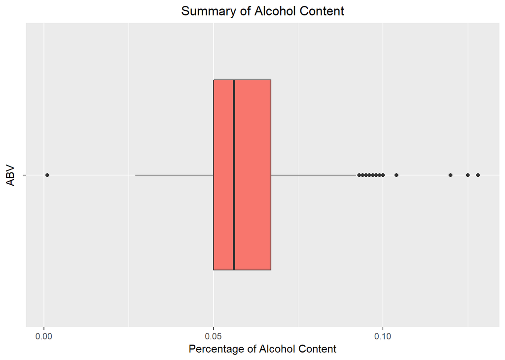

```r
ggplot(BeerNBrew, aes(y=ABV, x=" ", fill= " ")) + geom_boxplot() + ggtitle("Summary of Alcohol Content") +
  theme(plot.title = element_text(hjust = .5), legend.position = "none") + ylab("Percentage of Alcohol Content") +
  xlab("ABV") + coord_flip()
```

## Question 7: ABV and IBU Correlation. There is a positive correlatin between the two.

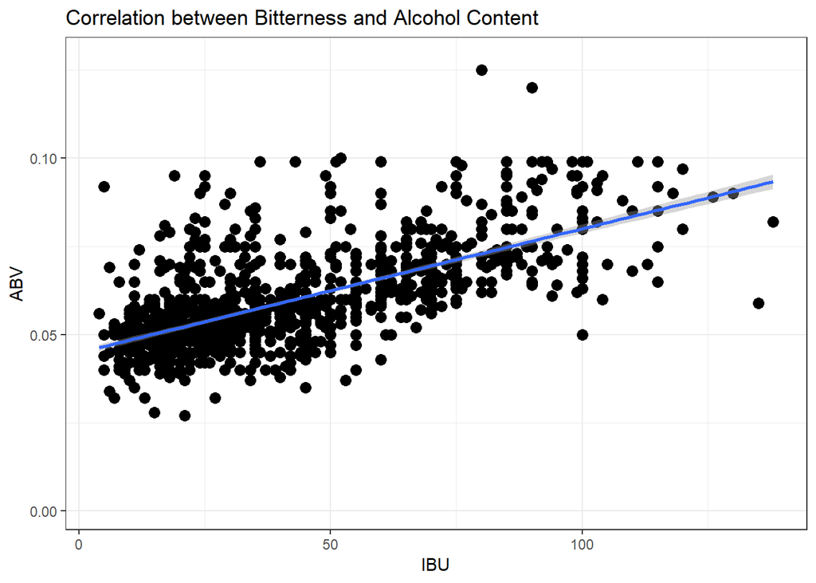

```r
library(ggplot2)
p1 <- ggplot(BeerNBrew, aes(IBU, ABV)) +
  geom_point(size = 3) + geom_smooth(method='lm') +
  labs(x = "IBU", y = "ABV") + theme_bw() +
  theme(legend.position = "top", legend.text = element_text(size = 12),
        legend.title = element_text(size = 14))+ggtitle("Correlation between Bitterness and Alcohol Content")
p1
```